# Tarea03

## Reto 2: Matriz de correlaciones

### 1. Objetivos:

```
- Aprender a generar e interpretar una matriz de correlaciones
```

### 2. Desarrollo:

Para este Reto vamos a utilizar un conjunto de datos llamado 'wine_quality_red-clean.csv'. Este dataset tiene datos acerca de diversos tipos de vino rojo. Incluye datos acerca de la composición química de los vinos y una variable 'quality' que es una evaluación de la calidad del vino que va del 1 al 10.

Aquí esta [el link](https://archive.ics.uci.edu/ml/datasets/wine+quality) de donde proviene este dataset.

```python
#Antes de comenzar importamos las librerias necesarias
import pandas as pd
import seaborn as sns
import matplotlib.pyplot as plt
```

```python
# Lee aquí tu dataset
df = pd.read_csv('wine_quality_red-clean.csv',index_col=0)
df.head()
# Es recomendable realizar una pequeña exploración antes de pasar a la siguiente sección
```

|  | fixed_acidity | volatile_acidity | citric_acid | residual_sugar | chlorides | free_sulfur_dioxide | total_sulfur_dioxide | density | pH | sulphates | alcohol | quality |
| --- | --- | --- | --- | --- | --- | --- | --- | --- | --- | --- | --- | --- |
| 0 | 7.4 | 0.70 | 0.00 | 1.9 | 0.076 | 11.0 | 34.0 | 0.9978 | 3.51 | 0.56 | 9.4 | 5 |
| 1 | 7.8 | 0.88 | 0.00 | 2.6 | 0.098 | 25.0 | 67.0 | 0.9968 | 3.20 | 0.68 | 9.8 | 5 |
| 2 | 7.8 | 0.76 | 0.04 | 2.3 | 0.092 | 15.0 | 54.0 | 0.9970 | 3.26 | 0.65 | 9.8 | 5 |
| 3 | 11.2 | 0.28 | 0.56 | 1.9 | 0.075 | 17.0 | 60.0 | 0.9980 | 3.16 | 0.58 | 9.8 | 6 |
| 4 | 7.4 | 0.70 | 0.00 | 1.9 | 0.076 | 11.0 | 34.0 | 0.9978 | 3.51 | 0.56 | 9.4 | 5 |

```python
df.info()
```

```
<class 'pandas.core.frame.DataFrame'>
Index: 1599 entries, 0 to 1598
Data columns (total 12 columns):
 #   Column                Non-Null Count  Dtype
---  ------                --------------  -----
 0   fixed_acidity         1599 non-null   float64
 1   volatile_acidity      1599 non-null   float64
 2   citric_acid           1599 non-null   float64
 3   residual_sugar        1599 non-null   float64
 4   chlorides             1599 non-null   float64
 5   free_sulfur_dioxide   1599 non-null   float64
 6   total_sulfur_dioxide  1599 non-null   float64
 7   density               1599 non-null   float64
 8   pH                    1599 non-null   float64
 9   sulphates             1599 non-null   float64
 10  alcohol               1599 non-null   float64
 11  quality               1599 non-null   int64
dtypes: float64(11), int64(1)
memory usage: 162.4 KB
```

```python
df['quality'].unique()
```

```
array([5, 6, 7, 4, 8, 3], dtype=int64)
```

```python
#damn bro, el vino ni a bueno llega zzz
```

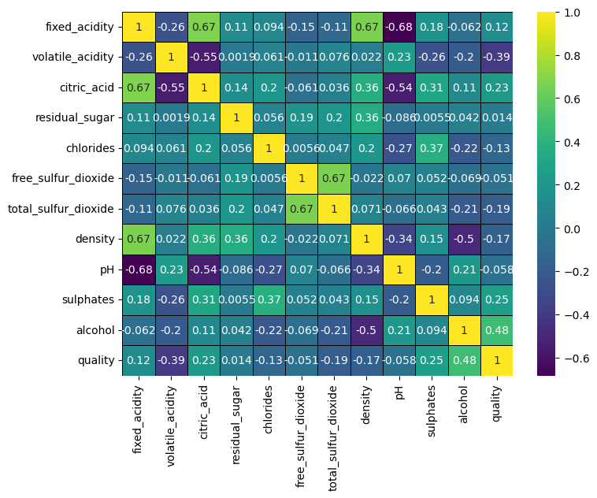

```python
#Bueno, no hay datos categoricos por loq que no ocupamos droppear a nadie
plt.figure(figsize=(8, 6))
b = sns.heatmap(df.corr(), annot=True, linewidths=.5,linecolor='black',cmap='viridis')
```

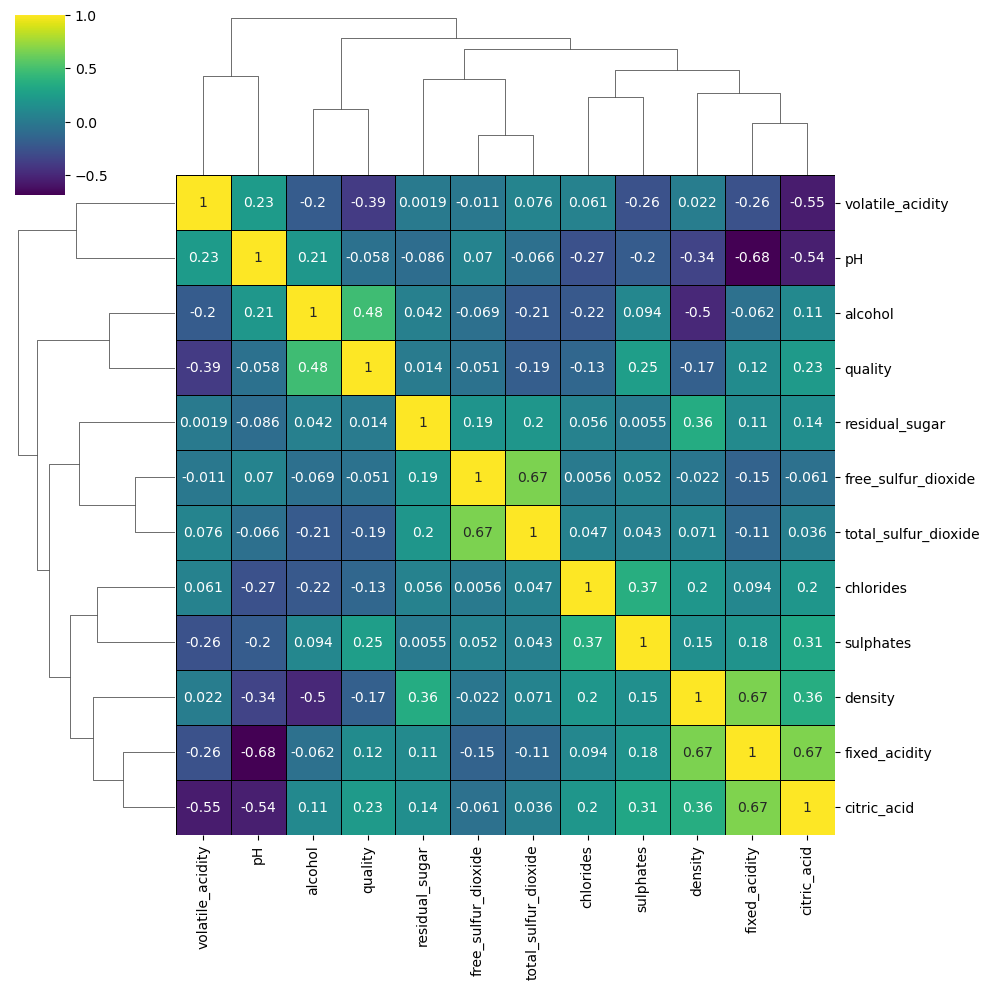

```python
sns.clustermap(df.corr(), annot=True, linewidths=.5,linecolor='black',cmap='viridis')
#No se como leer esto, pero se supone que dice cosas interesantes.
```

Vamos a explorar las relaciones que existen entre estas variables. Para esto, genera un heatmap para visualizar el coeficiente de correlación de Pearson entre todas las variables del dataset. Añade un título y utiliza [la documentación](https://seaborn.pydata.org/generated/seaborn.heatmap.html) para modificar la gráfica a tu gusto y hacerla más atractiva y comprensible. Puedes modificar el grosor de las líneas entre los cuadros, el color de los cuadros, el rango total del espectro de colores, etc. Después de tener lista tu visualización, responde las siguientes preguntas y coméntalas con tus compañeros y la experta:

1. ¿Qué variables no tienen una correlación lineal entre ellas?

R: Bueno, debemos tener 1 o -1, y entre más cerca este de esos valores hay una correlación lineal más fuerte.

Nula nula, ninguna pero si muy cercanas a cero.

1. ¿Qué variables tienen correlaciones positivas?

todas tienen al menos una correlación con otra variable que es positiva

1. ¿Qué par de variables tiene la mayor correlación positiva?

citric_acid (0.67), density (0.67) con fixed_acidity

free_sulfur_dioxide con total_sulfur_dioxide (0.67)

1. ¿Qué variables tienen correlaciones negativas?

fixed_acidity con free_sulfur_dioxide (-0.15), total_sulfur_dioxide (-0.11), pH (-0.68) por nombrar unas pero nuevamente todas tienen al menos una correlación con coeficeinte negativo entre ellas.

1. ¿Qué par de variables tiene la mayor correlación negativa?

fixed_acidity con pH (-0.68)

1. ¿Tienes algunas hipótesis acerca de por qué existen estas correlaciones (o porque no existen)?

acidity es obvia con citric_acid y density depende de la concentración de ciertos ingredientes.

fixed_acidity con pH porque el pH es la medida de que tan cerca del realm de acidez está

```python
# Realiza aquí tu visualización
```